# DataViz for SocScientists Notes

Caitlin S. Ducate

5/21/2020

```r
# Setup
myPackages <- c("tidyverse", "broom", "coefplot", "cowplot",
                 "gapminder", "GGally", "ggrepel", "ggridges", "gridExtra",
                 "here", "interplot", "margins", "maps", "mapproj",
                 "mapdata", "MASS", "quantreg", "rlang", "scales",
                 "survey", "srvyr", "viridis", "viridisLite", "devtools")
install.packages(myPackages)
devtools::install_github("kjhealy/socviz")
library(here)
```

## Chapter 1: Look At Data

**Why look at data?**

- Because numbers can be misleading & describe a variety of patterns that will only come to light when we can see all of the data at once

**Principles of bad figure making**

- “Chart junk”: extraneous stuff that doesn’t add to the data story
  - In some cases, though, a memorable graph will have a bit of superfluous design if it is clever
- Bad data: the data being presented tell a misleading story
- Problems with perception: the chart may be free of junk, but human visual perception will be misled by the chart’s layout or dimensions

**Human Perception**

- Humans are better at seeing gradients when they are all the same hue and chroma but vary in luminance
- Need to be careful with color choice to make sure colors step through the options as intended
  - In other words, colors can be misleading if picked wrong (e.g. one color can unintentionally stand out more than the others)
- Shape and color are two “channels” that can encode information visually about your data
  - Color channel seems to work better than shape channel
  - Should try to avoid showing data through multiple channels
- Gestalt Rules
  - Proximity: things close together seem related
  - Similarity: things that look alike seem related
  - Connection: things visually tied together seem related
  - Continuity: Partially hidden objects are perceptually completed
  - Figure & ground: visual elements seen in either the foreground or the background
  - Common fate: elements moving in the same direction are seen as a unit (e.g. school of fish)

**Decoding Graphs**

- Humans do best when judging the relative position of things on a common scale
- Humans do worst when judging quantities as angles or areas (esp. areas of circles)

**Honest & Good Judgment**

- Not always good rules of thumb for what is an honest representation
  - Sometimes it makes sense not to start your Y-axis at 0, and if your axes are labeled, not necessarily misleading

## Chapter 2: Getting Started

```r
# Load in libraries
library(tidyverse)
```

```r
library(socviz)
```

- Mostly an overview of R & RStudio
- A `tibble` is a tidyverse data.frame

```r
# Tiny data set from socviz package
class(titanic)
```

```
## [1] "data.frame"
```

```r
# Turn titanic into a tidyverse tibble
titanic_tb <- as_tibble(titanic)
titanic_tb
```

```
## # A tibble: 4 x 4
##   fate     sex        n percent
##   <fct>    <fct>  <dbl>   <dbl>
## 1 perished male    1364    62
## 2 perished female   126     5.7
## 3 survived male     367    16.7
## 4 survived female   344    15.6
```

- The package `haven` is also good for reading in data of various formats
- Apparently “tidy” data is long format rather than wide format
  - **Note**: I am intrigued

### Making my first figure

```r
library(gapminder)
gapminder
```

```
## # A tibble: 1,704 x 6
##    country     continent  year lifeExp      pop gdpPercap
##    <fct>       <fct>     <int>   <dbl>    <int>     <dbl>
##  1 Afghanistan Asia       1952    28.8  8425333      779.
##  2 Afghanistan Asia       1957    30.3  9240934      821.
##  3 Afghanistan Asia       1962    32.0 10267083      853.
##  4 Afghanistan Asia       1967    34.0 11537966      836.
##  5 Afghanistan Asia       1972    36.1 13079460      740.
##  6 Afghanistan Asia       1977    38.4 14880372      786.
##  7 Afghanistan Asia       1982    39.9 12881816      978.
##  8 Afghanistan Asia       1987    40.8 13867957      852.
##  9 Afghanistan Asia       1992    41.7 16317921      649.
## 10 Afghanistan Asia       1997    41.8 22227415      635.
## # … with 1,694 more rows
```

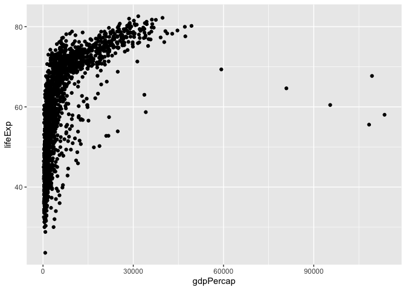

```r
p <- ggplot(data = gapminder,
            mapping = aes(x = gdpPercap, y = lifeExp))
p + geom_point()
```

# Chapter 3: Make a Plot

## How `ggplot` works

- plot elements called *aesthetic mappings*
- Type of plot is called a *geom*
- `ggplot` is part of the *tidyverse*, so it expects data in long format (where every observation is a row)
- Basic template for a plot:

```r
p <- ggplot(data = <data>,
            mapping = aes(<aesthetic1> = <variable1>,
                          <aesthetic2> = <variable2>))
p <- geom_<type>(<...>) +
     scale_<mapping>_<type>()
```

## Trying out a plot

```r
library(gapminder)
gapminder
```

```
## # A tibble: 1,704 x 6
##    country     continent  year lifeExp      pop gdpPercap
##    <fct>       <fct>     <int>   <dbl>    <int>     <dbl>
##  1 Afghanistan Asia       1952    28.8  8425333      779.
##  2 Afghanistan Asia       1957    30.3  9240934      821.
##  3 Afghanistan Asia       1962    32.0 10267083      853.
##  4 Afghanistan Asia       1967    34.0 11537966      836.
##  5 Afghanistan Asia       1972    36.1 13079460      740.
##  6 Afghanistan Asia       1977    38.4 14880372      786.
##  7 Afghanistan Asia       1982    39.9 12881816      978.
##  8 Afghanistan Asia       1987    40.8 13867957      852.
##  9 Afghanistan Asia       1992    41.7 16317921      649.
## 10 Afghanistan Asia       1997    41.8 22227415      635.
## # … with 1,694 more rows
```

```r
# First tell ggplot() what data we are using
p <- ggplot(data = gapminder)
p <- ggplot(data = gapminder,
            mapping = aes(x = gdpPercap,
                          y = lifeExp))

# How much info does ggplot() have right now?
str(p)
```

[output not shown]

[output cut: 18 more lines]

[output not shown]

- The asethetic mappings indicate with variables in the data will be represented by visual elements
- However, to draw the plot, you need to add a layer to the plot

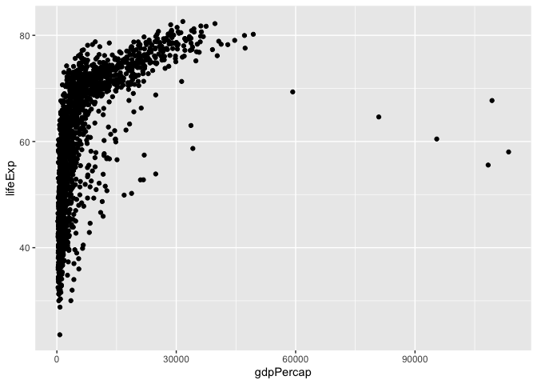

```r
p + geom_point()
```

## Steps to Making a Plot

1. Tell `ggplot()` what our data is: `data = ...`
2. Tell `ggplot()` what relationships we want to see: `mapping = aes(...)`
3. Tell `ggplot` how we want to see the relationships: `p + geom_<type>`
4. Layer on geoms as needed by added them to the `p` object one at a time
5. Use additional features to adjust scales, labels, tick marks, & titles

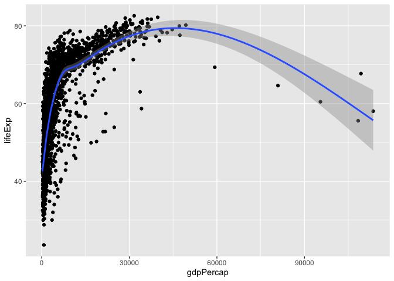

```r
# Add a smooth function over the data points
## By default, geom_smooth() includes the standard error!! That is cool
p + geom_point() + geom_smooth()
```

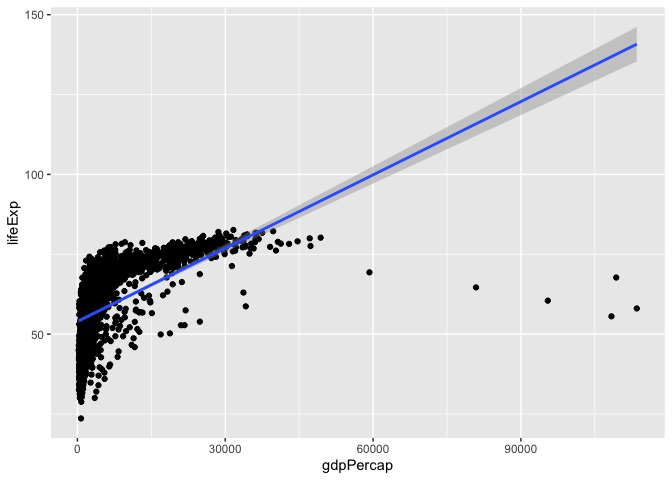

```r
# Because the output says geom_smooth() is using method = 'gam', suggests we can tell it to use other methods
p + geom_point() + geom_smooth(method = "lm")
```

Hmm….The data is all bunched up. Let’s log it!

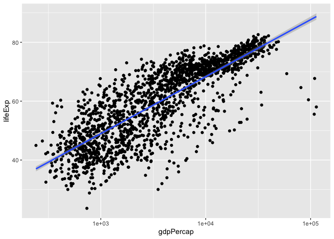

```r
p <- ggplot(data = gapminder,
            mapping = aes(x = gdpPercap,
                          y = lifeExp))

p + geom_point() +
    geom_smooth(method = "lm") + # Note: there is a typo in the book that sets `method = "gam"`
    scale_x_log10()
```

Now to clean up the scale labels:

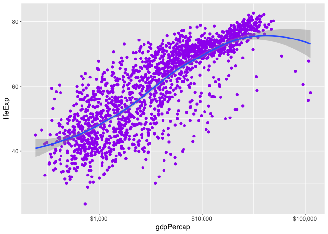

```r
p + geom_point(color = "purple") +
    geom_smooth(method = "loess") +
    scale_x_log10(labels = scales::dollar)
```

Playing with the color and transparency (`alpha`) of the points. Modifying the transparency is good for when you have a lot of overlapping data points

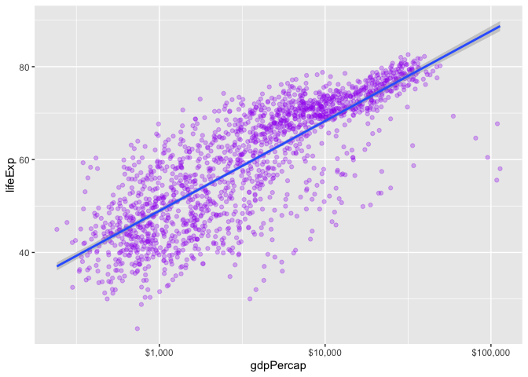

```r
p + geom_point(color = "purple", alpha = 0.3) +
    geom_smooth(method = "lm") +
    scale_x_log10(labels = scales::dollar)
```

Polishing up the labels

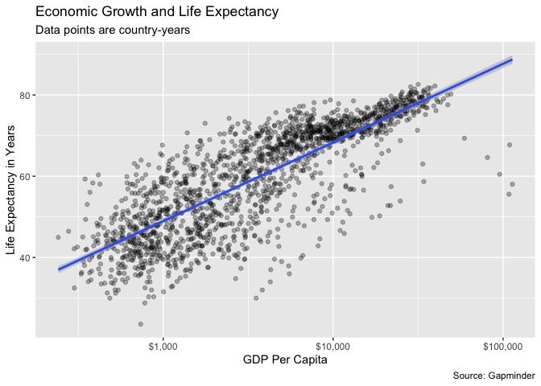

```r
p <- ggplot(data = gapminder,
            mapping = aes(x = gdpPercap,
                          y = lifeExp))
p + geom_point(alpha = 0.3) +
    geom_smooth(method = "lm") +
    scale_x_log10(labels = scales::dollar) +
    labs(x = "GDP Per Capita",
         y = "Life Expectancy in Years",
         title = "Economic Growth and Life Expectancy",
         subtitle = "Data points are country-years",
         caption = "Source: Gapminder")
```

Other fun graph stuff

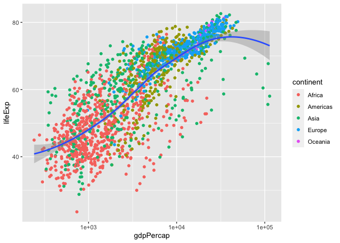

```r
p <- ggplot(data = gapminder, mapping = aes(x = gdpPercap, y = lifeExp))
p + geom_point(mapping = aes(color = continent)) +
    geom_smooth(method = "loess") +
    scale_x_log10()
```

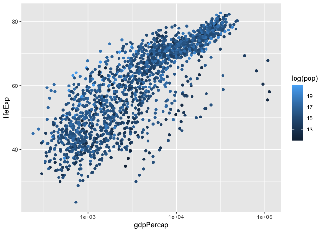

```r
p <- ggplot(data = gapminder,
            mapping = aes(x = gdpPercap,
                          y = lifeExp))
p + geom_point(mapping = aes(color = log(pop))) +
    scale_x_log10()
```

### Saving plots

General saving method. Works to save the most recently made figure.

```r
ggsave(filename = "my_figure.png")
```

To save a specific figure, using the `here()` package to handle files in folders

```r
p <- ggplot(data = gapminder,
            mapping = aes(x = gdpPercap,
                          y = lifeExp))
p_out <- p + geom_point(mapping = aes(color = log(pop)), alpha = 0.7) +
              scale_x_log10(labels = scales::dollar) +
              labs(x = "GDP Per Capita",
                   y = "Life expectancy in years",
                   title = "Economic Growth and Life Expectancy",
                   subtitle = "Data points are country-years",
                   caption = "Source: Gapminder")

# First argument in here() is the name of the subfolder
ggsave(here("Figures", "lifeexp_vs_gdp_gradient.pdf"), plot = p_out)
```

**Note about saving figure file formats**

- PDF is the best option for publication because PDF is acceptable for most journals *and* is a vector-formatted file type
  - This makes resizing easy without ruining the resolution
- Additionally, it’s underlying langauge is Postscript, which is the language of a lot of moder typesetting and printing
- PNG & JPG are *raster* based formats that are not easily resized